# Lab 3: Gesture Recognition using Convolutional Neural Networks

**Deadlines**: Feb 8, 5:00PM

**Late Penalty**: There is a penalty-free grace period of one hour past the deadline. Any work that is submitted between 1 hour and 24 hours past the deadline will receive a 20% grade deduction. No other late work is accepted. Quercus submission time will be used, not your local computer time. You can submit your labs as many times as you want before the deadline, so please submit often and early.

**Grading TAs**: Geoff Donoghue

This lab is based on an assignment developed by Prof. Lisa Zhang.

This lab will be completed in two parts. In Part A you will you will gain experience gathering your own data set (specifically images of hand gestures), and understand the challenges involved in the data cleaning process. In Part B you will train a convolutional neural network to make classifications on different hand gestures. By the end of the lab, you should be able to:

1. Generate and preprocess your own data
2. Load and split data for training, validation and testing
3. Train a Convolutional Neural Network
4. Apply transfer learning to improve your model

Note that for this lab we will not be providing you with any starter code. You should be able to take the code used in previous labs, tutorials and lectures and modify it accordingly to complete the tasks outlined below.

### What to submit

**Submission for Part A:**  
Submit a zip file containing your images. Three images each of American Sign Language gestures for letters A - I (total of 27 images). You will be required to clean the images before submitting them. Details are provided under Part A of the handout.

Individual image file names should follow the convention of student-number_Alphabet_file-number.jpg (e.g. 100343434_A_1.jpg).

**Submission for Part B:**  
Submit a PDF file containing all your code, outputs, and write-up from parts 1-5. You can produce a PDF of your Google Colab file by going to **File > Print** and then save as PDF. The Colab instructions has more information. Make sure to review the PDF submission to ensure that your answers are easy to read. Make sure that your text is not cut off at the margins.

**Do not submit any other files produced by your code.**

Include a link to your colab file in your submission.

Please use Google Colab to complete this assignment. If you want to use Jupyter Notebook, please complete the assignment and upload your Jupyter Notebook file to Google Colab for submission.

## Colab Link

Include a link to your colab file here

Colab Link: https://colab.research.google.com/drive/1rv57DqBXls7r93l1Bh9yd0Xok5p666-x?usp=sharing

## Part A. Data Collection [10 pt]

So far, we have worked with data sets that have been collected, cleaned, and curated by machine learning researchers and practitioners. Datasets like MNIST and CIFAR are often used as toy examples, both by students and by researchers testing new machine learning models.

In the real world, getting a clean data set is never that easy. More than half the work in applying machine learning is finding, gathering, cleaning, and formatting your data set.

The purpose of this lab is to help you gain experience gathering your own data set, and understand the challenges involved in the data cleaning process.

### American Sign Language

American Sign Language (ASL) is a complete, complex language that employs signs made by moving the hands combined with facial expressions and postures of the body. It is the primary language of many North Americans who are deaf and is one of several communication options used by people who are deaf or hard-of-hearing.

The hand gestures representing English alphabet are shown below. This lab focuses on classifying a subset of these hand gesture images using convolutional neural networks. Specifically, given an image of a hand showing one of the letters A-I, we want to detect which letter is being represented.

[figure not shown]

### Generating Data

We will produce the images required for this lab by ourselves. Each student will collect, clean and submit three images each of Americal Sign Language gestures for letters A - I (total of 27 images) Steps involved in data collection

1. Familiarize yourself with American Sign Language gestures for letters from A - I (9 letters).
2. Take three pictures at slightly different orientation for each letter gesture using your mobile phone.
   - Ensure adequate lighting while you are capturing the images.
   - Use a white wall as your background.
   - Use your right hand to create gestures (for consistency).
   - Keep your right hand fairly apart from your body and any other obstructions.
   - Avoid having shadows on parts of your hand.
3. Transfer the images to your laptop for cleaning.

### Cleaning Data

To simplify the machine learning the task, we will standardize the training images. We will make sure that all our images are of the same size (224 x 224 pixels RGB), and have the hand in the center of the cropped regions.

You may use the following applications to crop and resize your images:

**Mac**

- Use Preview: – Holding down CMD + Shift will keep a square aspect ratio while selecting the hand area. – Resize to 224x224 pixels.

**Windows 10**

- Use Photos app to edit and crop the image and keep the aspect ratio a square.
- Use Paint to resize the image to the final image size of 224x224 pixels.

**Linux**

- You can use GIMP, imagemagick, or other tools of your choosing. You may also use online tools such as http://picresize.com All the above steps are illustrative only. You need not follow these steps but following these will ensure that you produce a good quality dataset. You will be judged based on the quality of the images alone. Please do not edit your photos in any other way. You should not need to change the aspect ratio of your image. You also should not digitally remove the background or shadows—instead, take photos with a white background and minimal shadows.

### Accepted Images

Images will be accepted and graded based on the criteria below

1. The final image should be size 224x224 pixels (RGB).
2. The file format should be a .jpg file.
3. The hand should be approximately centered on the frame.
4. The hand should not be obscured or cut off.
5. The photos follows the ASL gestures posted earlier.
6. The photos were not edited in any other way (e.g. no electronic removal of shadows or background).

### Submission

Submit a zip file containing your images. There should be a total of 27 images (3 for each category)

1. Individual image file names should follow the convention of student-number_Alphabet_file-number.jpg (e.g. 100343434_A_1.jpg)
2. Zip all the images together and name it with the following convention: last-name_student-number.zip (e.g. last-name_100343434.zip).
3. Submit the zipped folder. We will be anonymizing and combining the images that everyone submits. We will announce when the combined data set will be available for download.

[figure not shown]

## Part B. Building a CNN [50 pt]

For this lab, we are not going to give you any starter code. You will be writing a convolutional neural network from scratch. You are welcome to use any code from previous labs, lectures and tutorials. You should also write your own code.

You may use the PyTorch documentation freely. You might also find online tutorials helpful. However, all code that you submit must be your own.

Make sure that your code is vectorized, and does not contain obvious inefficiencies (for example, unecessary for loops, or unnecessary calls to unsqueeze()). Ensure enough comments are included in the code so that your TA can understand what you are doing. It is your responsibility to show that you understand what you write.

**This is much more challenging and time-consuming than the previous labs.** Make sure that you give yourself plenty of time by starting early.

```python
from google.colab import drive #connect colab with my google drive
drive.mount('/content/drive')
```

### 1. Data Loading and Splitting [5 pt]

Download the anonymized data provided on Quercus. To allow you to get a heads start on this project we will provide you with sample data from previous years. Split the data into training, validation, and test sets.

Note: Data splitting is not as trivial in this lab. We want our test set to closely resemble the setting in which our model will be used. In particular, our test set should contain hands that are never seen in training!

Explain how you split the data, either by describing what you did, or by showing the code that you used. Justify your choice of splitting strategy. How many training, validation, and test images do you have?

For loading the data, you can use plt.imread as in Lab 1, or any other method that you choose. You may find torchvision.datasets.ImageFolder helpful. (see https://pytorch.org/docs/stable/torchvision/datasets.html?highlight=image%20folder#torchvision.datasets.ImageFolder )

```python
#unzip the dataset from my google drive to /root/dataset
!unzip '/content/drive/MyDrive/Lab_3_Gesture_Dataset.zip' -d '/root/datasets'
```

```python
#unzip the dataset from my google drive to /root/dataset
!unzip '/content/drive/MyDrive/Liu_1003784746.zip' -d '/root/datasets'
```

```python
import numpy as np
import time
import torch
import sklearn
import torch.nn as nn
import torch.nn.functional as F
import torch.optim as optim
import torchvision
from torch.utils.data.sampler import SubsetRandomSampler
import torchvision.transforms as transforms
from sklearn.preprocessing import LabelEncoder
```

```python
def get_relevant_indices(dataset, classes, target_classes):
    indices = []
    for i in range(len(dataset)):
        # Check if the label is in the target classes
        label_index = dataset[i][1] # ex: 3
        label_class = classes[label_index] # ex: 'cat'
        if label_class in target_classes:
            indices.append(i)
    return indices

def get_data_loader(target_classes, batch_size, path, overfit):

    classes = ('A', 'B', 'C', 'D',
               'E', 'F', 'G', 'H', 'I')
    ########################################################################
    # The output of torchvision datasets are PILImage images of range [0, 1].
    # We transform them to Tensors of normalized range [-1, 1]. And also crop each input to 224 * 224
    transform = transforms.Compose(
        [transforms.Resize(224),
         transforms.CenterCrop(224), transforms.ToTensor(),
         transforms.Normalize((0.5, 0.5, 0.5), (0.5, 0.5, 0.5))])
    # Load data
    dataset = torchvision.datasets.ImageFolder(path,
                                               transform=transform)
    # Get the list of indices to sample from
    relevant_indices = get_relevant_indices(dataset, classes, target_classes)

    # Split into train and validation and test
    #ratio: 8:1:1
    np.random.seed(1000) # Fixed numpy random seed for reproducible shuffling
    np.random.shuffle(relevant_indices)
    print("Data total length is: ", len(relevant_indices))
    if(overfit == False):
      splitOne = int(len(relevant_indices) * 0.8)
      #split at 80% since the amount in each class is different, this is an approximation
      splitTwo = int(len(relevant_indices) * 0.9)

      # split into training and validation indices
      relevant_train_indices, relevant_val_indices, relevant_test_indices =(
        relevant_indices[:splitOne], relevant_indices[splitOne:splitTwo], relevant_indices[splitTwo:])
      train_sampler = SubsetRandomSampler(relevant_train_indices)
      train_loader = torch.utils.data.DataLoader(dataset, batch_size=batch_size,
                                                num_workers=1, sampler=train_sampler)
      val_sampler = SubsetRandomSampler(relevant_val_indices)
      val_loader = torch.utils.data.DataLoader(dataset, batch_size=batch_size,
                                              num_workers=1, sampler=val_sampler)
      test_sampler = SubsetRandomSampler(relevant_test_indices)
      test_loader = torch.utils.data.DataLoader(dataset, batch_size=batch_size,
                                                num_workers=1, sampler=test_sampler)
    else:
      sampler_indice = relevant_indices[:100]
      train_sampler = SubsetRandomSampler(sampler_indice)
      train_loader = torch.utils.data.DataLoader(dataset, batch_size=batch_size,
                                                num_workers=1, sampler=train_sampler)
      val_sampler = SubsetRandomSampler(sampler_indice)
      val_loader = torch.utils.data.DataLoader(dataset, batch_size=batch_size,
                                              num_workers=1, sampler=val_sampler)
      test_sampler = SubsetRandomSampler(sampler_indice)
      test_loader = torch.utils.data.DataLoader(dataset, batch_size=batch_size,
                                                num_workers=1, sampler=test_sampler)

    return train_loader, val_loader, test_loader, classes
```

```python
train_loader, val_loader, test_loader, classes = get_data_loader(
    target_classes=["A", "B", "C", "D", "E", "F", "G", "H", "I"],
    batch_size=1, path = "/root/datasets/Lab_3b_Gesture_Dataset", overfit = False) # One image per batch
print('Num training images: ', len(train_loader))
print('Num validation images: ', len(val_loader))
print('Num test images: ', len(test_loader))
```

```
Data total length is:  2431
Num training images:  1944
Num validation images:  243
Num test images:  244
```

### 2. Model Building and Sanity Checking [15 pt]

### Part (a) Convolutional Network - 5 pt

Build a convolutional neural network model that takes the (224x224 RGB) image as input, and predicts the gesture letter. Your model should be a subclass of nn.Module. Explain your choice of neural network architecture: how many layers did you choose? What types of layers did you use? Were they fully-connected or convolutional? What about other decisions like pooling layers, activation functions, number of channels / hidden units?

the CNN architecture uses six layers, 1. convolution, 2. pool, 3. convolution,

1. pool, 5. fully connected, 6. fully connected.

The model will use ReLu for activation function.

The kernel size for two convolution layers will be 5. The output will be map two nine outputs, so the last fc layer's output should be 9.

To determine number of channels in each layer, I did the computation: no padding layer: 0 =(i - k) + 1

layer 1: input 224x224x3, after conv1: 220x220x5

layer 2: input 220x220x5, after pool(size 2): 110x110x5

layer 3: input 110x110x5, after conv2: 106x106x10

layer 4: input 10x106x10, after pool: 53x53x10

layer 5: input 53x53x10, flatten: 300

layer 6: input 300, output 9

```python
class Net(nn.Module):
    def __init__(self):
        super(Net, self).__init__()
        self.name = "large"
        self.conv1 = nn.Conv2d(3, 5, 5)
        self.pool = nn.MaxPool2d(2, 2)
        self.conv2 = nn.Conv2d(5, 10, 5)
        self.fc1 = nn.Linear(53*53*10, 300)
        self.fc2 = nn.Linear(300, 9)

    def forward(self, x):
        x = self.pool(F.relu(self.conv1(x)))
        x = self.pool(F.relu(self.conv2(x)))
        x = x.view(-1, 53*53*10)
        x = F.relu(self.fc1(x))
        x = self.fc2(x)
        x = x.squeeze(1) # Flatten to [batch_size]
        return x
```

### Part (b) Training Code - 5 pt

Write code that trains your neural network given some training data. Your training code should make it easy to tweak the usual hyperparameters, like batch size, learning rate, and the model object itself. Make sure that you are checkpointing your models from time to time (the frequency is up to you). Explain your choice of loss function and optimizer.

Since the model dues with a multi-class classification, we use multiclass coross-entropy loss function since it applys softmax activation function on the final layer to obtain class probabilities. "nn.CrossEntropyLoss()"

Optimizer will be SGD with Momentum, which is frequently used in cnn model.

The training code would mainly be "train_net" function, which use model, batch_size, learning_rate and num_epoch as inputs. This helps tweak the hyperparameters easily

```python
def evaluate(net, loader, criterion):
    """ Evaluate the network on the validation set.

     Args:
         net: PyTorch neural network object
         loader: PyTorch data loader for the validation set
         criterion: The loss function
     Returns:
         err: A scalar for the avg classification error over the validation set
         loss: A scalar for the average loss function over the validation set
     """
    total_loss = 0
    total_err = 0
    total_epoch = 0
    total_val = 0
    for i, data in enumerate(loader, 0):
        inputs, labels = data
        outputs = net(inputs)
        #calculate the loss
        loss = criterion(outputs, labels)
        total_loss += loss.item()* inputs.size(0)
        for index, target in enumerate(outputs):
          total_val += 1
          if torch.argmax(target) != labels[index]:
            total_err += 1
    return  total_err/total_val, total_loss/total_val
```

```python
def train_net(net, batch_size, learning_rate, num_epochs, path, overfit = False):
    ########################################################################
    # Train a classifier on 9 characters
    target_classes = ['A', 'B', 'C', 'D',
               'E', 'F', 'G', 'H', 'I']
    ########################################################################
    # Fixed PyTorch random seed for reproducible result
    torch.manual_seed(1000)
    ########################################################################
    # Obtain the PyTorch data loader objects to load batches of the datasets
    train_loader, val_loader, test_loader, classes = get_data_loader(
            target_classes, batch_size, path, overfit)
    ########################################################################
    # Define the Loss function and optimizer
    criterion = nn.CrossEntropyLoss()
    optimizer = optim.SGD(net.parameters(), lr=learning_rate, momentum=0.9)
    ########################################################################
    # Set up some numpy arrays to store the training/test loss/erruracy
    train_err = np.zeros(num_epochs)
    train_loss = np.zeros(num_epochs)
    val_err = np.zeros(num_epochs)
    val_loss = np.zeros(num_epochs)
    ########################################################################
    # Train the network
    # Loop over the data iterator and sample a new batch of training data
    # Get the output from the network, and optimize our loss function.
    start_time = time.time()
    for epoch in range(num_epochs):  # loop over the dataset multiple times
        total_train_loss = 0
        total_train_err = 0
        total_epoch = 0
        num_train_total = 0
        for i, data in enumerate(train_loader, 0):
            # Get the inputs
            inputs, labels = data
            # Zero the parameter gradients
            optimizer.zero_grad()
            # Forward pass, backward pass, and optimize
            outputs = net(inputs)
            #calculate the loss
            loss = criterion(outputs, labels)
            loss.backward()
            optimizer.step()
            # Calculate the statistics
            for index, target in enumerate(outputs):
                num_train_total += 1
                if torch.argmax(target) != labels[index]:
                    total_train_err += 1
            total_train_loss += loss.item()* inputs.size(0)
        train_err[epoch] = total_train_err / num_train_total
        train_loss[epoch] = total_train_loss / num_train_total
        val_err[epoch], val_loss[epoch] = evaluate(net, val_loader, criterion)
        print(("Epoch {}: Train err: {}, Train loss: {} |"+
               "Validation err: {}, Validation loss: {}").format(
                   epoch + 1,
                   train_err[epoch],
                   train_loss[epoch],
                   val_err[epoch],
                   val_loss[epoch]))
    print('Finished Training')
    end_time = time.time()
    elapsed_time = end_time - start_time
    print("Total time elapsed: {:.2f} seconds".format(elapsed_time))

    import matplotlib.pyplot as plt
    plt.title("Train vs Validation Error")
    n = len(train_err) # number of epochs
    plt.plot(range(1,n+1), train_err, label="Train")
    plt.plot(range(1,n+1), val_err, label="Validation")
    plt.xlabel("Epoch")
    plt.ylabel("Error")
    plt.legend(loc='best')
    plt.show()
    plt.title("Train vs Validation Loss")
    plt.plot(range(1,n+1), train_loss, label="Train")
    plt.plot(range(1,n+1), val_loss, label="Validation")
    plt.xlabel("Epoch")
    plt.ylabel("Loss")
    plt.legend(loc='best')
    plt.show()
```

### Part (c) “Overfit” to a Small Dataset - 5 pt

One way to sanity check our neural network model and training code is to check whether the model is capable of “overfitting” or “memorizing” a small dataset. A properly constructed CNN with correct training code should be able to memorize the answers to a small number of images quickly.

Construct a small dataset (e.g. just the images that you have collected). Then show that your model and training code is capable of memorizing the labels of this small data set.

With a large batch size (e.g. the entire small dataset) and learning rate that is not too high, You should be able to obtain a 100% training accuracy on that small dataset relatively quickly (within 200 iterations).

```
Data total length is:  2431
Epoch 1: Train err: 0.93, Train loss: 2.192415714263916 |Validation err: 0.84, Validation loss: 2.1854530572891235
Epoch 2: Train err: 0.87, Train loss: 2.1852680444717407 |Validation err: 0.78, Validation loss: 2.1701208353042603
Epoch 3: Train err: 0.77, Train loss: 2.165750503540039 |Validation err: 0.75, Validation loss: 2.1509984731674194
Epoch 4: Train err: 0.73, Train loss: 2.1456249952316284 |Validation err: 0.67, Validation loss: 2.1198593378067017
Epoch 5: Train err: 0.68, Train loss: 2.110651731491089 |Validation err: 0.64, Validation loss: 2.062742829322815
Epoch 6: Train err: 0.62, Train loss: 2.041003704071045 |Validation err: 0.58, Validation loss: 1.9509207606315613
Epoch 7: Train err: 0.58, Train loss: 1.9118279218673706 |Validation err: 0.51, Validation loss: 1.7325952053070068
Epoch 8: Train err: 0.48, Train loss: 1.673169195652008 |Validation err: 0.39, Validation loss: 1.3782002925872803
Epoch 9: Train err: 0.33, Train loss: 1.2724838256835938 |Validation err: 0.24, Validation loss: 0.9154309034347534
Epoch 10: Train err: 0.26, Train loss: 0.9068786799907684 |Validation err: 0.15, Validation loss: 0.5888400077819824
Epoch 11: Train err: 0.18, Train loss: 0.6072373688220978 |Validation err: 0.14, Validation loss: 0.38038595020771027
Epoch 12: Train err: 0.18, Train loss: 0.5303015261888504 |Validation err: 0.24, Validation loss: 1.5052935481071472
Epoch 13: Train err: 0.23, Train loss: 1.3606008887290955 |Validation err: 0.19, Validation loss: 1.2499196529388428
Epoch 14: Train err: 0.33, Train loss: 2.3709827065467834 |Validation err: 0.42, Validation loss: 1.7463713884353638
Epoch 15: Train err: 0.29, Train loss: 1.4210335612297058 |Validation err: 0.34, Validation loss: 1.3248823285102844
Epoch 16: Train err: 0.31, Train loss: 1.149482011795044 |Validation err: 0.22, Validation loss: 0.8067395985126495
Epoch 17: Train err: 0.22, Train loss: 0.8828687071800232 |Validation err: 0.17, Validation loss: 0.9046154320240021
Epoch 18: Train err: 0.2, Train loss: 0.900244802236557 |Validation err: 0.15, Validation loss: 0.869657963514328
Epoch 19: Train err: 0.15, Train loss: 0.8127051889896393 |Validation err: 0.14, Validation loss: 0.5840023159980774
Epoch 20: Train err: 0.09, Train loss: 0.5037015229463577 |Validation err: 0.08, Validation loss: 0.231624573469162
Epoch 21: Train err: 0.07, Train loss: 0.21454234421253204 |Validation err: 0.08, Validation loss: 0.18695825338363647
Epoch 22: Train err: 0.1, Train loss: 0.20705831795930862 |Validation err: 0.05, Validation loss: 0.11259202659130096
Epoch 23: Train err: 0.05, Train loss: 0.10188721120357513 |Validation err: 0.0, Validation loss: 0.0443774051964283
Epoch 24: Train err: 0.0, Train loss: 0.03307117987424135 |Validation err: 0.04, Validation loss: 0.20080109685659409
Epoch 25: Train err: 0.05, Train loss: 0.22401547245681286 |Validation err: 0.0, Validation loss: 0.022698531625792384
Epoch 26: Train err: 0.03, Train loss: 0.05784354358911514 |Validation err: 0.11, Validation loss: 2.1016896963119507
Epoch 27: Train err: 0.04, Train loss: 1.2309663016349077 |Validation err: 0.23, Validation loss: 2.0637412667274475
Epoch 28: Train err: 0.19, Train loss: 1.4293500185012817 |Validation err: 0.05, Validation loss: 0.27284637093544006
Epoch 29: Train err: 0.08, Train loss: 0.6562596037983894 |Validation err: 0.08, Validation loss: 0.6198789477348328
Epoch 30: Train err: 0.12, Train loss: 0.6084303706884384 |Validation err: 0.12, Validation loss: 0.5143531113862991
Epoch 31: Train err: 0.11, Train loss: 0.5465881526470184 |Validation err: 0.05, Validation loss: 0.5606117844581604
Epoch 32: Train err: 0.05, Train loss: 0.5674055516719818 |Validation err: 0.02, Validation loss: 0.5069727599620819
Epoch 33: Train err: 0.01, Train loss: 0.44883522391319275 |Validation err: 0.01, Validation loss: 0.2787633091211319
Epoch 34: Train err: 0.01, Train loss: 0.23885062336921692 |Validation err: 0.03, Validation loss: 0.14391644299030304
Epoch 35: Train err: 0.02, Train loss: 0.1203775554895401 |Validation err: 0.01, Validation loss: 0.044801611453294754
Epoch 36: Train err: 0.01, Train loss: 0.03293685941025615 |Validation err: 0.01, Validation loss: 0.019639882259070873
Epoch 37: Train err: 0.01, Train loss: 0.017234849277883768 |Validation err: 0.01, Validation loss: 0.011983375297859311
Epoch 38: Train err: 0.0, Train loss: 0.00944873911794275 |Validation err: 0.0, Validation loss: 0.0056366376811638474
Epoch 39: Train err: 0.0, Train loss: 0.006204160861670971 |Validation err: 0.0, Validation loss: 0.0038365258369594812
Epoch 40: Train err: 0.0, Train loss: 0.005580447963438928 |Validation err: 0.0, Validation loss: 0.0013039675541222095
Finished Training
Total time elapsed: 133.71 seconds
```

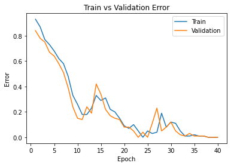

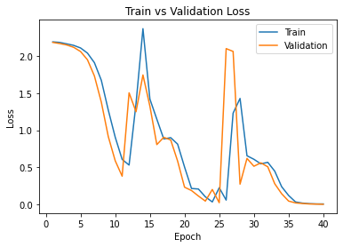

```python
large_net = Net()
train_net(large_net, batch_size=50, learning_rate=0.01, num_epochs=40, path="/root/datasets/Lab_3b_Gesture_Dataset", overfit = True)
#train the first 100 pictures in dataset as a "small dataset"
#by setting overfit equals to true, train dataset and validation dataset is the same see "get_train_loader" function
```

As we can see, when training the first 100 pictures in the dataset, also setting test and validation the same range of data,

the model has the ability to memorize the data.

### 3. Hyperparameter Search [10 pt]

### Part (a) - 1 pt

List 3 hyperparameters that you think are most worth tuning. Choose at least one hyperparameter related to the model architecture.

1. The batch size of the model
2. The hidden units inside the model
3. number of epoch

### Part (b) - 5 pt

Tune the hyperparameters you listed in Part (a), trying as many values as you need to until you feel satisfied that you are getting a good model. Plot the training curve of at least 4 different hyperparameter settings.

```
Data total length is:  2431
Epoch 1: Train err: 0.6790123456790124, Train loss: 1.9190452779516762 |Validation err: 0.45267489711934156, Validation loss: 1.2163313641960238
Epoch 2: Train err: 0.411522633744856, Train loss: 1.1935107588400076 |Validation err: 0.3497942386831276, Validation loss: 1.0139917265240548
Epoch 3: Train err: 0.32767489711934156, Train loss: 0.9556205609943641 |Validation err: 0.2674897119341564, Validation loss: 0.8427465913717639
Epoch 4: Train err: 0.23508230452674897, Train loss: 0.7166118730978711 |Validation err: 0.2962962962962963, Validation loss: 0.9594172165717607
Epoch 5: Train err: 0.21553497942386832, Train loss: 0.6224295562554779 |Validation err: 0.17695473251028807, Validation loss: 0.6316358030087663
Epoch 6: Train err: 0.13991769547325103, Train loss: 0.4055252094664937 |Validation err: 0.21810699588477367, Validation loss: 0.7321672895808279
Epoch 7: Train err: 0.10082304526748971, Train loss: 0.2953402448460889 |Validation err: 0.2551440329218107, Validation loss: 0.8713701745119605
Epoch 8: Train err: 0.06532921810699588, Train loss: 0.18710223237366833 |Validation err: 0.1646090534979424, Validation loss: 0.7713231103410446
Epoch 9: Train err: 0.05864197530864197, Train loss: 0.1779275902742405 |Validation err: 0.2222222222222222, Validation loss: 1.0100935260945387
Epoch 10: Train err: 0.05864197530864197, Train loss: 0.19768249488017933 |Validation err: 0.2839506172839506, Validation loss: 0.8889470610598968
Finished Training
Total time elapsed: 353.53 seconds
```

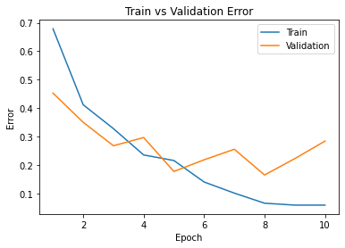

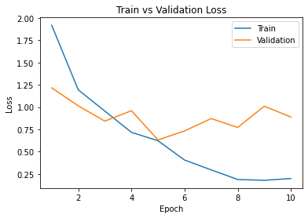

```python
#Batch size 50
#epoch 10
#original hidden units
one_net = Net()
train_net(one_net, batch_size=50, learning_rate=0.01, num_epochs=10, path="/root/datasets/Lab_3b_Gesture_Dataset", overfit = False)
```

```
Data total length is:  2431
Epoch 1: Train err: 0.7325102880658436, Train loss: 1.9542235898873443 |Validation err: 0.5061728395061729, Validation loss: 1.4684666640473982
Epoch 2: Train err: 0.4295267489711934, Train loss: 1.2206879290043082 |Validation err: 0.3497942386831276, Validation loss: 0.960879540983051
Epoch 3: Train err: 0.3497942386831276, Train loss: 0.9824659879560824 |Validation err: 0.27983539094650206, Validation loss: 0.8831511515158194
Epoch 4: Train err: 0.2829218106995885, Train loss: 0.8059778995352027 |Validation err: 0.31275720164609055, Validation loss: 0.9499164594053732
Epoch 5: Train err: 0.1697530864197531, Train loss: 0.4960976031459408 |Validation err: 0.31275720164609055, Validation loss: 0.9665542836051909
Epoch 6: Train err: 0.10905349794238683, Train loss: 0.3195373706803216 |Validation err: 0.26337448559670784, Validation loss: 1.1833698718191543
Epoch 7: Train err: 0.05401234567901234, Train loss: 0.15423223962087507 |Validation err: 0.23868312757201646, Validation loss: 1.0042127579327964
Epoch 8: Train err: 0.03343621399176955, Train loss: 0.09453586032403319 |Validation err: 0.2345679012345679, Validation loss: 1.0033847880952151
Epoch 9: Train err: 0.03292181069958848, Train loss: 0.09365587199079026 |Validation err: 0.17695473251028807, Validation loss: 0.9899011830120911
Epoch 10: Train err: 0.02109053497942387, Train loss: 0.06359058679831253 |Validation err: 0.2345679012345679, Validation loss: 1.2840435941523485
Finished Training
Total time elapsed: 390.00 seconds
```

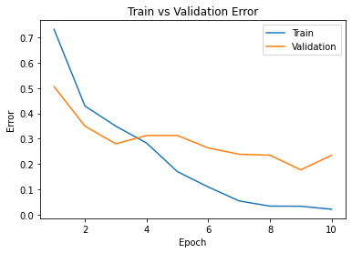

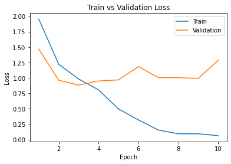

```python
#Batch size 20
#epoch 10
#original hidden units
two_net = Net()
train_net(two_net, batch_size=20, learning_rate=0.01, num_epochs=10, path="/root/datasets/Lab_3b_Gesture_Dataset", overfit = False)
```

```
Data total length is:  2431
Epoch 1: Train err: 0.6748971193415638, Train loss: 1.8068023270049705 |Validation err: 0.49382716049382713, Validation loss: 1.437470798139219
Epoch 2: Train err: 0.3986625514403292, Train loss: 1.1157912226861397 |Validation err: 0.2674897119341564, Validation loss: 0.9554473679252122
Epoch 3: Train err: 0.29989711934156377, Train loss: 0.8575959640397947 |Validation err: 0.2716049382716049, Validation loss: 0.8723352200700423
Epoch 4: Train err: 0.22633744855967078, Train loss: 0.6883876892151656 |Validation err: 0.25925925925925924, Validation loss: 0.8454385581330507
Epoch 5: Train err: 0.17952674897119342, Train loss: 0.49936061600844067 |Validation err: 0.21810699588477367, Validation loss: 0.6738643015853663
Epoch 6: Train err: 0.147119341563786, Train loss: 0.41171878173088833 |Validation err: 0.25925925925925924, Validation loss: 0.9433195810811019
Epoch 7: Train err: 0.102880658436214, Train loss: 0.29382071052697095 |Validation err: 0.22633744855967078, Validation loss: 0.9341117233773808
Epoch 8: Train err: 0.10390946502057613, Train loss: 0.3353939289572062 |Validation err: 0.27983539094650206, Validation loss: 0.9959644989221675
Epoch 9: Train err: 0.08590534979423868, Train loss: 0.24556737575198426 |Validation err: 0.2139917695473251, Validation loss: 1.1332294298297583
Epoch 10: Train err: 0.030349794238683128, Train loss: 0.09537202423129905 |Validation err: 0.26337448559670784, Validation loss: 1.3829458760626523
Finished Training
Total time elapsed: 554.39 seconds
```

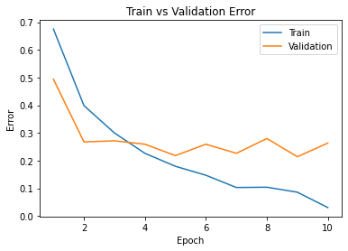

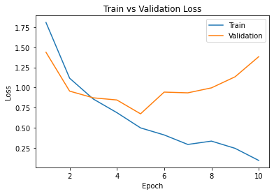

```python
#Batch size 20
#epoch 10
#advanced net with enhanced hidden units
#develop the fc layer to three layers
class AdvancedNet(nn.Module):
    def __init__(self):
        super(AdvancedNet, self).__init__()
        self.name = "AdvancedNet"
        self.conv1 = nn.Conv2d(3, 6, 5)
        self.pool = nn.MaxPool2d(2, 2)
        self.conv2 = nn.Conv2d(6, 10, 5)
        self.fc1 = nn.Linear(10 * 53 * 53, 1000)
        self.fc2 = nn.Linear(1000, 300)
        self.fc3 = nn.Linear(300, 9)

    def forward(self, x):
        x = self.pool(F.relu(self.conv1(x)))
        x = self.pool(F.relu(self.conv2(x)))
        x = x.view(-1, 10 * 53 * 53)
        x = F.relu(self.fc1(x))
        x = F.relu(self.fc2(x))
        x = self.fc3(x)
        x = x.squeeze(1) # Flatten to [batch_size]
        return x
three_net = AdvancedNet()
train_net(three_net, batch_size=20, learning_rate=0.01, num_epochs=10, path="/root/datasets/Lab_3b_Gesture_Dataset", overfit = False)
```

### Part (c) - 2 pt

Choose the best model out of all the ones that you have trained. Justify your choice.

According to the model tested above, I will use:

Batch size 20 epoch 10 original hidden units

"two_net" as the best model

It achieves the minimum validation error: 0.23

### Part (d) - 2 pt

Report the test accuracy of your best model. You should only do this step once and prior to this step you should have only used the training and validation data.

```python
classes = ('A', 'B', 'C', 'D',
               'E', 'F', 'G', 'H', 'I')
train_loader, val_loader, test_loader, classes = get_data_loader(
            classes, batch_size = 20, path = "/root/datasets/Lab_3b_Gesture_Dataset" , overfit = False)
criterion = nn.CrossEntropyLoss()
#evaluate the test loss and error
test_err, test_loss = evaluate(two_net, test_loader, criterion)
#print the test accuracy

print("test accuracy for my best model is: ", (1-test_err))
```

```
Data total length is:  2431
test accuracy for my best model is:  0.7254098360655737
```

### 4. Transfer Learning [15 pt]

For many image classification tasks, it is generally not a good idea to train a very large deep neural network model from scratch due to the enormous compute requirements and lack of sufficient amounts of training data.

One of the better options is to try using an existing model that performs a similar task to the one you need to solve. This method of utilizing a pre-trained network for other similar tasks is broadly termed **Transfer Learning**. In this assignment, we will use Transfer Learning to extract features from the hand gesture images. Then, train a smaller network to use these features as input and classify the hand gestures.

As you have learned from the CNN lecture, convolution layers extract various features from the images which get utilized by the fully connected layers for correct classification. AlexNet architecture played a pivotal role in establishing Deep Neural Nets as a go-to tool for image classification problems and we will use an ImageNet pre-trained AlexNet model to extract features in this assignment.

### Part (a) - 5 pt

Here is the code to load the AlexNet network, with pretrained weights. When you first run the code, PyTorch will download the pretrained weights from the internet.

```python
import torchvision.models
alexnet = torchvision.models.alexnet(pretrained=True)
```

```
Downloading: "https://download.pytorch.org/models/alexnet-owt-4df8aa71.pth" to /root/.cache/torch/hub/checkpoints/alexnet-owt-4df8aa71.pth
```

The alexnet model is split up into two components: *alexnet.features* and *alexnet.classifier*. The first neural network component, *alexnet.features*, is used to compute convolutional features, which are taken as input in *alexnet.classifier*.

The neural network alexnet.features expects an image tensor of shape Nx3x224x224 as input and it will output a tensor of shape Nx256x6x6 . (N = batch size).

Compute the AlexNet features for each of your training, validation, and test data. Here is an example code snippet showing how you can compute the AlexNet features for some images (your actual code might be different):

```python
# img = ... a PyTorch tensor with shape [N,3,224,224] containing hand images ...
features = alexnet.features(img)
```

**Save the computed features**. You will be using these features as input to your neural network in Part (b), and you do not want to re-compute the features every time. Instead, run *alexnet.features* once for each image, and save the result.

```python
def save_Alex_feature(inputpath):
  import os
  import shutil
  #delete previous feature data if existing
  if os.path.isdir("/root/features/train"):
    shutil.rmtree("/root/features/train")
  if os.path.isdir("/root/features/val"):
    shutil.rmtree("/root/features/val")
  if os.path.isdir("/root/features/test"):
    shutil.rmtree("/root/features/test")

  feature_path = "/root/features"
  classes = ('A', 'B', 'C', 'D',
                'E', 'F', 'G', 'H', 'I')
  train_loader, val_loader, test_loader, classes = get_data_loader(
              classes, batch_size = 1, path = inputpath , overfit = False)

  num_train = 0
  os.mkdir("/root/features/train")
  for img, label in train_loader:
    features = alexnet.features(img)
    features_tensor = torch.from_numpy(features.detach().numpy())

    folder_name = feature_path + '/train/' + str(classes[label])
    if not os.path.isdir(folder_name):
      os.mkdir(folder_name)
    torch.save(features_tensor.squeeze(0), folder_name + '/' + str(num_train) + '.tensor')
    num_train += 1

  num_val = 0
  os.mkdir("/root/features/val")
  for img, label in val_loader:
    features = alexnet.features(img)
    features_tensor = torch.from_numpy(features.detach().numpy())

    folder_name = feature_path + '/val/' + str(classes[label])
    if not os.path.isdir(folder_name):
      os.mkdir(folder_name)
    torch.save(features_tensor.squeeze(0), folder_name + '/' + str(num_val) + '.tensor')
    num_val += 1

  num_test = 0
  os.mkdir("/root/features/test")
  for img, label in test_loader:
    features = alexnet.features(img)
    features_tensor = torch.from_numpy(features.detach().numpy())

    folder_name = feature_path + '/test/' + str(classes[label])
    if not os.path.isdir(folder_name):
      os.mkdir(folder_name)
    torch.save(features_tensor.squeeze(0), folder_name + '/' + str(num_test) + '.tensor')
    num_test += 1
  print("save all feature outputs into feature path")


save_Alex_feature(inputpath = "/root/datasets/Lab_3b_Gesture_Dataset")
```

```
Data total length is:  2431
save all feature outputs into feature path
```

```python
def get_alex_loader(classes, batch_size):
  feature_path = "/root/features"
  np.random.seed(1000)
  train_features = torchvision.datasets.DatasetFolder(feature_path + '/train', loader=torch.load, extensions=('.tensor'))
  val_features = torchvision.datasets.DatasetFolder(feature_path + '/val', loader=torch.load, extensions=('.tensor'))
  test_features = torchvision.datasets.DatasetFolder(feature_path + '/test', loader=torch.load, extensions=('.tensor'))

  train_indices = get_relevant_indices(train_features, classes, classes)
  train_sampler = SubsetRandomSampler(train_indices)
  train_loader = torch.utils.data.DataLoader(train_features, batch_size=batch_size,
                                            num_workers=1, sampler = train_sampler)

  val_indices = get_relevant_indices(val_features, classes, classes)
  val_sampler = SubsetRandomSampler(val_indices)
  val_loader = torch.utils.data.DataLoader(val_features, batch_size=batch_size,
                                            num_workers=1, sampler = val_sampler)
  test_indices = get_relevant_indices(test_features, classes, classes)
  test_sampler = SubsetRandomSampler(test_indices)
  test_loader = torch.utils.data.DataLoader(test_features, batch_size=batch_size,
                                            num_workers=1, sampler = test_sampler)
  return train_loader, val_loader, test_loader

def train_Alexnet(net, batch_size, learning_rate, num_epochs):
    target_classes = ['A', 'B', 'C', 'D',
               'E', 'F', 'G', 'H', 'I']
    train_loader, val_loader, test_loader = get_alex_loader(target_classes, batch_size)

    criterion = nn.CrossEntropyLoss()
    optimizer = optim.SGD(net.parameters(), lr=learning_rate, momentum=0.9)
    train_err = np.zeros(num_epochs)
    train_loss = np.zeros(num_epochs)
    val_err = np.zeros(num_epochs)
    val_loss = np.zeros(num_epochs)

    start_time = time.time()
    for epoch in range(num_epochs):  # loop over the dataset multiple times
        total_train_loss = 0
        total_train_err = 0
        total_epoch = 0
        num_train_total = 0
        for i, data in enumerate(train_loader, 0):
            # Get the inputs
            inputs, labels = data
            # Zero the parameter gradients
            optimizer.zero_grad()
            # Forward pass, backward pass, and optimize
            outputs = net(inputs)
            #calculate the loss
            loss = criterion(outputs, labels)
            loss.backward()
            optimizer.step()
            # Calculate the statistics
            for index, target in enumerate(outputs):
                num_train_total += 1
                if torch.argmax(target) != labels[index]:
                    total_train_err += 1
            total_train_loss += loss.item()* inputs.size(0)
        train_err[epoch] = total_train_err / num_train_total
        train_loss[epoch] = total_train_loss / num_train_total
        val_err[epoch], val_loss[epoch] = evaluate(net, val_loader, criterion)
        print(("Epoch {}: Train err: {}, Train loss: {} |"+
               "Validation err: {}, Validation loss: {}").format(
                   epoch + 1,
                   train_err[epoch],
                   train_loss[epoch],
                   val_err[epoch],
                   val_loss[epoch]))
    print('Finished Training')
    end_time = time.time()
    elapsed_time = end_time - start_time
    print("Total time elapsed: {:.2f} seconds".format(elapsed_time))

    import matplotlib.pyplot as plt
    plt.title("Train vs Validation Error")
    n = len(train_err) # number of epochs
    plt.plot(range(1,n+1), train_err, label="Train")
    plt.plot(range(1,n+1), val_err, label="Validation")
    plt.xlabel("Epoch")
    plt.ylabel("Error")
    plt.legend(loc='best')
    plt.show()
    plt.title("Train vs Validation Loss")
    plt.plot(range(1,n+1), train_loss, label="Train")
    plt.plot(range(1,n+1), val_loss, label="Validation")
    plt.xlabel("Epoch")
    plt.ylabel("Loss")
    plt.legend(loc='best')
    plt.show()
```

```python
##check loader shape here
loaderA, loaderB, loaderC = get_alex_loader(classes, 10)
for data, label in loaderA:
  print("data's shape: ", data.shape)
  print("label's shape: ", label.shape)
  break
```

```
data's shape:  torch.Size([10, 256, 6, 6])
label's shape:  torch.Size([10])
```

### Part (b) - 3 pt

Build a convolutional neural network model that takes as input these AlexNet features, and makes a prediction. Your model should be a subclass of nn.Module.

Explain your choice of neural network architecture: how many layers did you choose? What types of layers did you use: fully-connected or convolutional? What about other decisions like pooling layers, activation functions, number of channels / hidden units in each layer?

Here is an example of how your model may be called:

Since the Alex model has changed the input from 224x224x3 to 256x6x6

we could see that Alex model has initially lower the size of the data input

this could be similar to 1 layer of convolution and pooling.

To keep the model bahave similar(or even better) than the original model developed in part 2.

I will use 4 layers in total:

o = (i-k)+1 for no padding layer 1: conv layer (kernel size 3)input 256x6x6 output 1024x4x4 (6-3)+1

layer 2: pooling layer (size 2)input 1024x4x4 output 1024x2x2

layer 3: FC layer input 1024x2x2 output 300(flatten)

layer 4: FC layer 300 output 9

Also the output should be passed through the softmax function to ensure the prob add to 1 at the end

```python
# features = ... load precomputed alexnet.features(img) ...
# output = model(features)
# prob = F.softmax(output)
class Net_Alex(nn.Module):
    def __init__(self):
        super(Net_Alex, self).__init__()
        self.name = "Net_Alex"
        self.conv1 = nn.Conv2d(256, 1024, 3)
        self.pool = nn.MaxPool2d(2, 2)
        self.fc1 = nn.Linear(1024 * 2 * 2, 300)
        self.fc2 = nn.Linear(300, 9)

    def forward(self, x):
        x = self.pool(F.relu(self.conv1(x)))
        x = x.view(-1, 1024 * 2 * 2)
        x = F.relu(self.fc1(x))
        x = self.fc2(x)
        x = x.squeeze(1) # Flatten to [batch_size]
        return F.softmax(x, dim=1)
```

### Part (c) - 5 pt

Train your new network, including any hyperparameter tuning. Plot and submit the training curve of your best model only.

Note: Depending on how you are caching (saving) your AlexNet features, PyTorch might still be tracking updates to the **AlexNet weights**, which we are not tuning. One workaround is to convert your AlexNet feature tensor into a numpy array, and then back into a PyTorch tensor.

```
Epoch 1: Train err: 0.5390946502057613, Train loss: 1.985940979096134 |Validation err: 0.29218106995884774, Validation loss: 1.6910533272189858
Epoch 2: Train err: 0.23405349794238683, Train loss: 1.630642936553484 |Validation err: 0.20164609053497942, Validation loss: 1.5830925364553192
Epoch 3: Train err: 0.17386831275720166, Train loss: 1.5563571938761958 |Validation err: 0.17695473251028807, Validation loss: 1.5485836169356673
Epoch 4: Train err: 0.09876543209876543, Train loss: 1.4817683922410503 |Validation err: 0.10699588477366255, Validation loss: 1.4893628927905864
Epoch 5: Train err: 0.06893004115226338, Train loss: 1.4447710962943088 |Validation err: 0.13168724279835392, Validation loss: 1.506614930835771
Epoch 6: Train err: 0.05298353909465021, Train loss: 1.43144232991301 |Validation err: 0.09053497942386832, Validation loss: 1.4667911289160143
Epoch 7: Train err: 0.046296296296296294, Train loss: 1.4236323212890467 |Validation err: 0.08641975308641975, Validation loss: 1.4682404371936626
Epoch 8: Train err: 0.044238683127572016, Train loss: 1.4176340046733495 |Validation err: 0.0823045267489712, Validation loss: 1.459199278933521
Epoch 9: Train err: 0.035493827160493825, Train loss: 1.409158534473843 |Validation err: 0.11934156378600823, Validation loss: 1.4907128761825248
Epoch 10: Train err: 0.03652263374485597, Train loss: 1.4116929210262534 |Validation err: 0.09053497942386832, Validation loss: 1.45885953834518
Finished Training
Total time elapsed: 121.21 seconds
```

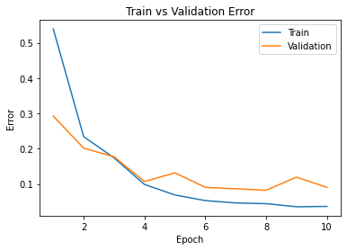

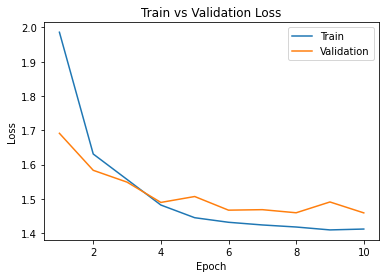

```python
alex_transfer = Net_Alex()
train_Alexnet(alex_transfer, batch_size = 20, learning_rate = 0.01, num_epochs = 10)
```

### Part (d) - 2 pt

Report the test accuracy of your best model. How does the test accuracy compare to Part 3(d) without transfer learning?

```python
train_loader, val_loader, test_loader = get_alex_loader(classes, 20)
criterion = nn.CrossEntropyLoss()
#evaluate the test loss and error
test_err, test_loss = evaluate(alex_transfer, test_loader, criterion)
#print the test accuracy

print("test accuracy for my alex-transfer model is: ", (1-test_err))
```

```
test accuracy for my alex-transfer model is:  0.9016393442622951
```

The test accuracy is 0.9, compared to part3(d) 0.72

We can conclude that utilizing a pre-trained network helps improve the accuracy of the model

### 5. Additional Testing [5 pt]

As a final step in testing we will be revisiting the sample images that you had collected and submitted at the start of this lab. These sample images should be untouched and will be used to demonstrate how well your model works at identifying your hand guestures.

Using the best transfer learning model developed in Part 4. Report the test accuracy on your sample images and how it compares to the test accuracy obtained in Part 4(d)? How well did your model do for the different hand guestures? Provide an explanation for why you think your model performed the way it did?

I will use the 27 picture I took as input

```python
import os
if os.path.isdir("/root/finalTest"):
    shutil.rmtree("/root/finalTest")
os.mkdir("/root/finalTest")
input_path = "/root/datasets/Liu_1003784746"
transform = transforms.Compose(
        [transforms.Resize(224),
         transforms.CenterCrop(224), transforms.ToTensor(),
         transforms.Normalize((0.5, 0.5, 0.5), (0.5, 0.5, 0.5))])
# Load data
dataset = torchvision.datasets.ImageFolder(path, transform=transform)
# Get the list of indices to sample from
relevant_indices = get_relevant_indices(dataset, classes, classes)
test_sampler = SubsetRandomSampler(relevant_indices)
raw_test_loader = torch.utils.data.DataLoader(dataset, batch_size=1,
                                          num_workers=1, sampler=test_sampler)
#save feature frow raw test_loader
num_test = 0
os.mkdir("/root/finalTest/test")
for img, label in raw_test_loader:
  features = alexnet.features(img)
  features_tensor = torch.from_numpy(features.detach().numpy())

  folder_name = '/root/finalTest/test/' + str(classes[label])
  if not os.path.isdir(folder_name):
    os.mkdir(folder_name)
  torch.save(features_tensor.squeeze(0), folder_name + '/' + str(num_test) + '.tensor')
  num_test += 1
print("save all feature outputs into feature path")

#get loader from alex features
test_features = torchvision.datasets.DatasetFolder('/root/finalTest/test', loader=torch.load, extensions=('.tensor'))
test_indices = get_relevant_indices(test_features, classes, classes)
test_sampler = SubsetRandomSampler(test_indices)
test_loader = torch.utils.data.DataLoader(test_features, batch_size=20,
                                          num_workers=1, sampler = test_sampler)
```

```
save all feature outputs into feature path
```

```python
#evaluate the 27 dataset with model from part 4
criterion = nn.CrossEntropyLoss()
#evaluate the test loss and error
test_err, test_loss = evaluate(alex_transfer, test_loader, criterion)
#print the test accuracy
print("test accuracy for my alex-transfer model with 27 pics dataset:  ", (1-test_err))
```

[output not shown]

Since my model does not see these 27 pics before, I can conclude that my model behaves quite well when meeting different dataset.

One of the reason I gain a higher accuracy is that the data i test is pretty small, only 27 pictures, compared to the dataset in 4(d). Therefore, to ensure a more "fair" testing result, I should generate a same-size test dataset as 4(d). And those data should not be touched by model before during the training process.